# Projet Analyse de données : Analyse des comportements et des préférences des utilisateurs des smartphones

2022-05-03

# I)Statistique Descriptive :

```r
library(readxl)
AD <- read_excel("C:/Users/user/OneDrive/Bureau/Smartphones.xlsx")
```

La base de données Smartphones est construite à partir d’un questionnaire destiné à des individus ayant des différentes catégories socio-professionnelles et plusieurs classes d’âge. Les données contiennet principalement les domaines d’usage des smartphones dans un premier lieu et les critères sur lesquels s’appuient les utilisateurs en faisant leurs choix. la première colonne est une variable qualitative ordinale qui représente les classes d’âge. la deuxième colonne est une variable qualitative qui représente le sexe. la 3éme colonne est une variable qualtitative qui représente la classe socio-professionnelle. la 4éme colonne est une variable quantitative qui représenté le temps passé sur les smartphones. Les colonnes de 5 à 13 sont des variables quantitatives discrètes qui représentent la fréquence d’usage de smartphones dans chaque domaine. Les colonnes de 14 à 24 sont des variables quantitatives discrètes qui représentent l’importance du chaque critère pour l’utilisateur. Ces variables sont obtenues à partir d’un échelle de likert gradué de 1 à 5. les dernières colonnes indiquent si les individus apprécient les marques mentionnés dans la questionnaire ou pas : les variables sont qualitatives ayant pour valeur marque_y si l’utilisateur aime cette marque , marque_n sinon.

## 1.valeurs manquantes:

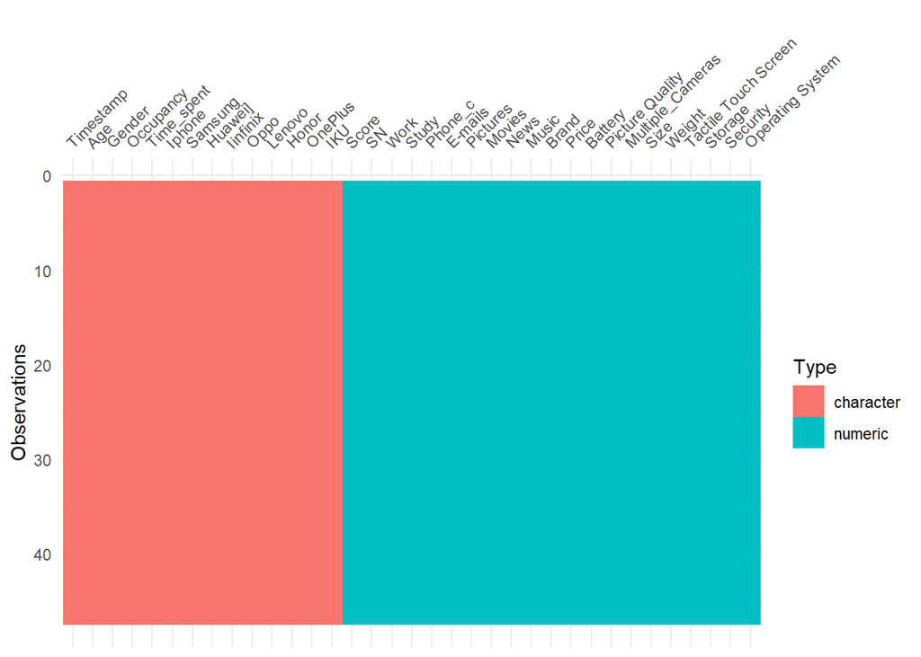

```r
library(visdat)
vis_dat(AD)
```

la base de données Smartphones ne contient pas des valeurs manquantes.

## 2.Camembert de sexe :

```r
library(lessR)
```

```
## >>> Note: Sexe is not in a data frame (table)
```

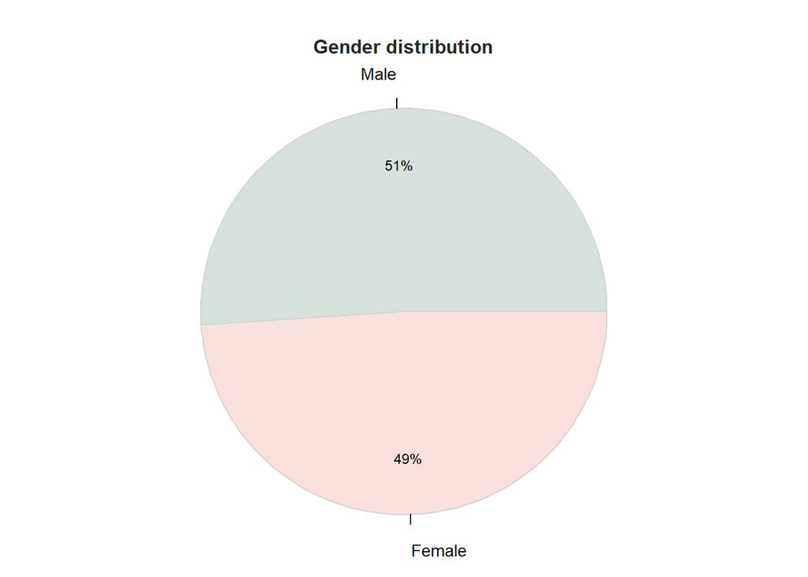

```
## >>> Suggestions
## PieChart(Sexe, hole=0)  # traditional pie chart
## PieChart(Sexe, values="%")  # display %'s on the chart
## PieChart(Sexe)  # bar chart
## Plot(Sexe)  # bubble plot
## Plot(Sexe, values="count")  # lollipop plot
##
## --- Sexe ---
##
##                 Male  Female    Total
## Frequencies:      24      23       47
## Proportions:   0.511   0.489    1.000
##
## Chi-squared test of null hypothesis of equal probabilities
##   Chisq = 0.021, df = 1, p-value = 0.884
```

```r
Male=sum(AD$Gender == "Male")
Female=sum(AD$Gender =="Female")

n=c(Male,Female)
Sexe=as.factor(c("Male","Female"))

gender=as.data.frame(cbind(Sexe,n))
PieChart(x=Sexe,y=n,gender,fill =c("#d8e2dc","#fae1dd"),values_color="Black",hole=0,main="Gender distribution")
```

- D’aprés le camembert on a 49% des femmes et 51% d’hommes donc l’échantillon est bien équilibré . ## 3.Diagramme en battons des classes d’âge:

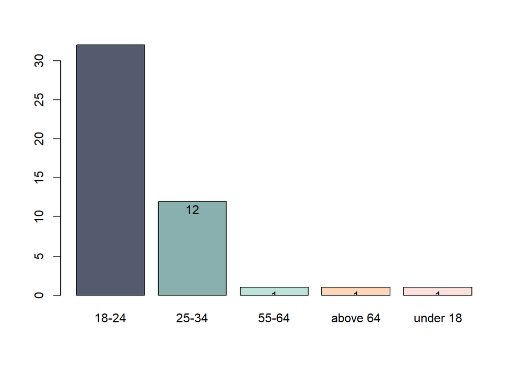

```r
colors=c("#555b6e","#89b0ae","#bee3db","#ffd6ba","#fae1dd")
b <- barplot(table(AD$Age),col=colors,ylim=c(0,30))
text(b[,1],table(AD$Age)-1,table(AD$Age))
```

- On remarque d’aprés les diagrammes à batons que la classe d’âge la plus fréquente est celle de la tranche d’âge entre 18 et 24 .

## 4.Temps passé sur le smartphone par catégorie socioprofessionnelle

```r
library(dplyr)
```

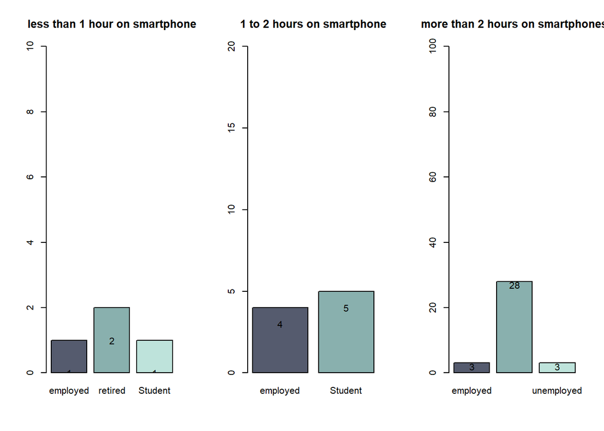

```r
Occupancy_Time=AD[5:6]

Time1=Occupancy_Time %>%
      filter(Time_spent=="less than 1 hour")
par(mfrow=c(1,3))
b1 <- barplot(table(Time1$Occupancy),col=colors,ylim=c(0,10),main = "less than 1 hour on smartphone")
text(b1[,1],table(Time1$Occupancy)-1,table(Time1$Occupancy))
Time2=Occupancy_Time %>%
      filter(Time_spent == "1-2 hours")
b2 <- barplot(table(Time2$Occupancy),col=colors,ylim=c(0,20),main="1 to 2 hours on smartphone")
text(b2[,1],table(Time2$Occupancy)-1,table(Time2$Occupancy))

Time3=Occupancy_Time %>%
      filter(Time_spent =="more than 2 hours")
b3 <- barplot(table(Time3$Occupancy),col=colors,ylim=c(0,100),main="more than 2 hours on smartphones")
text(b3[,1],table(Time3$Occupancy)-1,table(Time3$Occupancy))
```

- La visualisation de nombre d’heures passés sur les smartphones par catégorie socio-professionnelle montre que la plupart des étudiants passent plus que 2 heures sur leurs appareils.

# II)ACP :

## 1.pertinence de l’ACP :

[figure not shown]

```r
library(corrplot)
X=cor(as.matrix(Utilisation))
corrplot(X,type = 'lower')
```

- On a des fortes corrélations entre les variables donc l’ACP est pertinente.

## 2.choix de nombre d’axes :

```r
res.pca$eig
```

```
##        eigenvalue percentage of variance cumulative percentage of variance
## comp 1 3.70718447             46.3398059                          46.33981
## comp 2 2.14998461             26.8748077                          73.21461
## comp 3 1.16384754             14.5480943                          87.76271
## comp 4 0.33153862              4.1442328                          91.90694
## comp 5 0.27607772              3.4509714                          95.35791
## comp 6 0.22230295              2.7787868                          98.13670
## comp 7 0.11743466              1.4679333                          99.60463
## comp 8 0.03162942              0.3953678                         100.00000
```

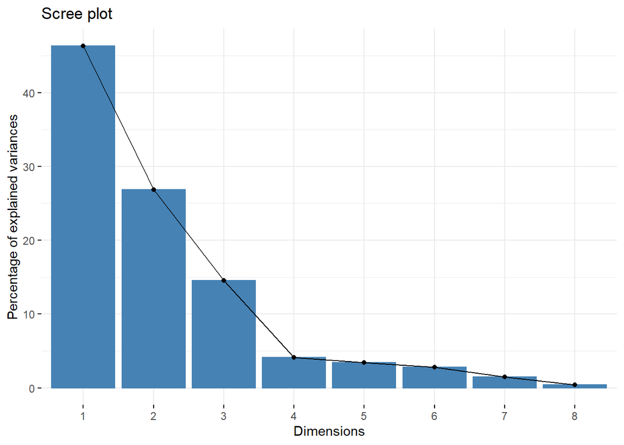

```r
fviz_screeplot(res.pca)
```

Critère de kaiser : On a trois valeurs propres supérieures à 1

Critère d’inertie cumulée : Les deux premiers axes ont un taux d’inertie cumulée de 73%.

Décision: On retient les deux premiers axes.

## 3.interprétation des axes :

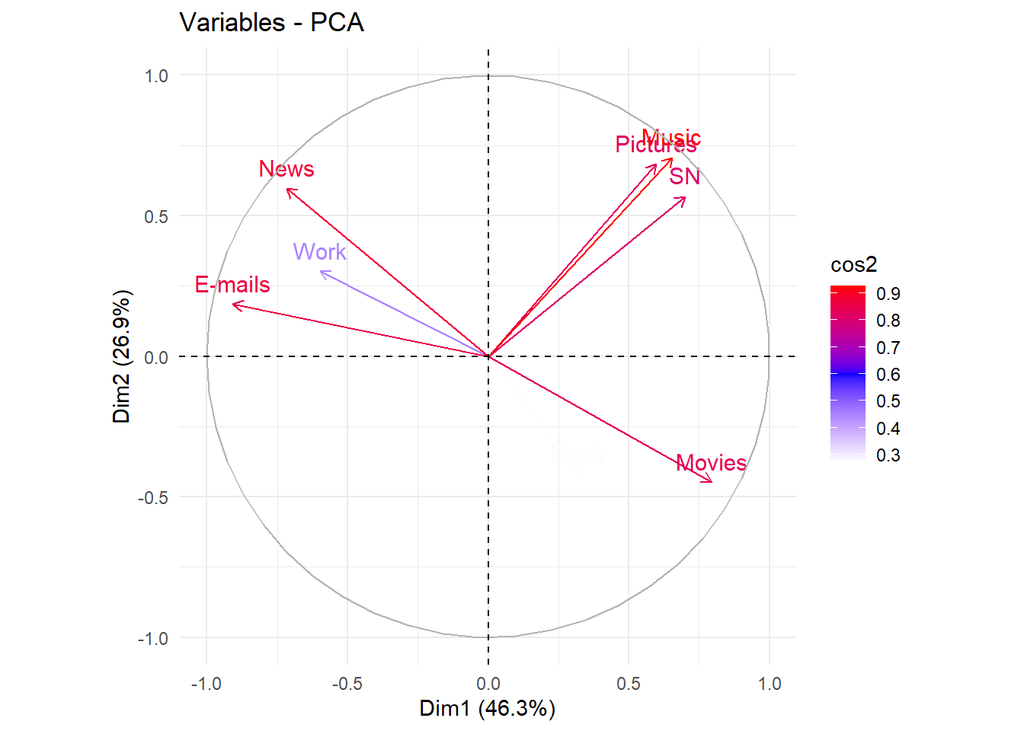

```r
fviz_pca_var(res.pca, axes=c(1,2), col.var="cos2") +
  scale_color_gradient2(low="white", mid="blue",
                        high="red", midpoint=0.6) +
  theme_minimal()
```

```r
res.pca$var$coord
```

```
##               Dim.1      Dim.2       Dim.3        Dim.4        Dim.5
## SN        0.7001430  0.5690008  0.04092265 -0.061455202  0.396299516
## Work     -0.5972191  0.3027389  0.64102660 -0.335598365 -0.039122197
## Study     0.3230068 -0.4165480  0.77866623  0.328350412  0.005655182
## E-mails  -0.9083537  0.1866007  0.20581678  0.006523839  0.126504757
## Pictures  0.5971247  0.6842861  0.26839163 -0.031979357 -0.187004235
## Movies    0.7953100 -0.4477219  0.16952123 -0.120735295  0.153670375
## News     -0.7168686  0.5979112 -0.02422281  0.286921377  0.128365336
## Music     0.6541387  0.7071348 -0.03489807  0.096723830 -0.162467229
```

## 4.interprétation de carte des individus :

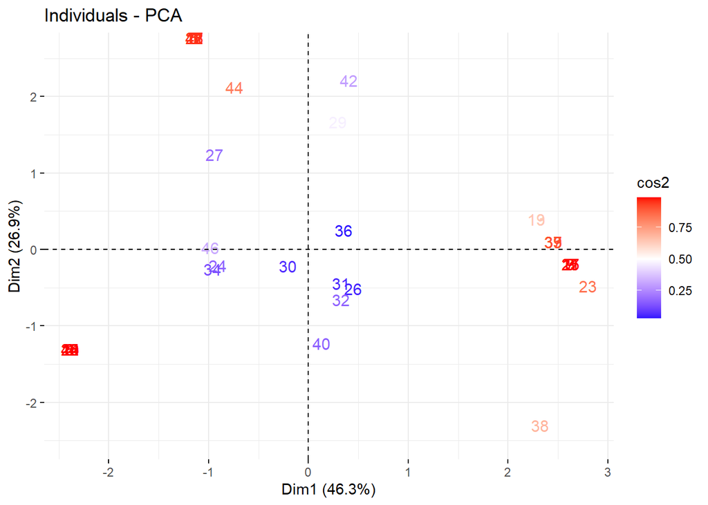

```r
fviz_pca_ind(res.pca,geom ="text",col.ind="cos2")+
scale_color_gradient2(low="blue", mid="white",
                      high="red", midpoint=0.5)
```

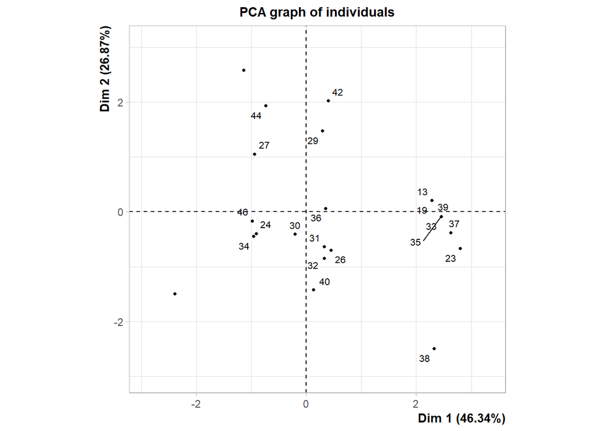

```r
plot.PCA(res.pca, axes=c(1, 2), choix="ind", cex=0.7)
```

# III) AFC

## 1.Introduction du tableau

Dans le cadre d’étude des classes socio-professionnels et le temps passés sur le smartphone , on réalise une analyse factorielle des correspondances dans le tableau croisée ci dessous :

```r
library(questionr)
AD$Time_spent <- as.factor(AD$Time_spent)
AD$Occupancy <- as.factor(AD$Occupancy)

tab<-table(AD$Occupancy,AD$Time_spent)
tab_eff=addmargins(tab)
tab_eff
```

```
##
##              1-2 hours less than 1 hour more than 2 hours Sum
##   employed           4                1                 3   8
##   retired            0                2                 0   2
##   Student            5                1                28  34
##   unemployed         0                0                 3   3
##   Sum                9                4                34  47
```

## 2. Profil lignes:

```r
profil_lignes=lprop(tab)
profil_lignes
```

```
##
##              1-2 hours less than 1 hour more than 2 hours Total
##   employed    50.0      12.5             37.5             100.0
##   retired      0.0     100.0              0.0             100.0
##   Student     14.7       2.9             82.4             100.0
##   unemployed   0.0       0.0            100.0             100.0
##   Ensemble    19.1       8.5             72.3             100.0
```

Parmi ceux qui sont employés 50% passent entre 1 et 2 heures sur les smartphones , 12.5% moins d’une heure et 37.5% plus que 2 heures.

## 3. Profil colonnes:

```r
profil_colonnes=cprop(tab)
profil_colonnes
```

```
##
##              1-2 hours less than 1 hour more than 2 hours Ensemble
##   employed    44.4      25.0              8.8              17.0
##   retired      0.0      50.0              0.0               4.3
##   Student     55.6      25.0             82.4              72.3
##   unemployed   0.0       0.0              8.8               6.4
##   Total      100.0     100.0            100.0             100.0
```

Parmi ceux qui passent entre 1 et 2 heures 44.4% sont employés et 55.6% des étudiants. ## 4. test khi-2:

```r
test<-chisq.test(tab)
test
```

```
##
##  Pearson's Chi-squared test
##
## data:  tab
## X-squared = 30.176, df = 6, p-value = 0.00003639
```

La valeur du χ2 est de 30.176

Le degré de liberté du χ2 est de (p−1)∗(q−1)=(4−1)∗(3−1)= 6

La p-value étant presque nulle (elle est de l’ordre de 10 puissance -5), on peut donc rejeter l’hypothèse d’indépendance : l’AFC est donc pertinente !

## 5.Choix de nombre d’axes :

```r
res.ca<-CA(tab,graph=F)
eig.val <- res.ca$eig
round(res.ca$eig,3)
```

```
##       eigenvalue percentage of variance cumulative percentage of variance
## dim 1      0.503                 78.344                            78.344
## dim 2      0.139                 21.656                           100.000
```

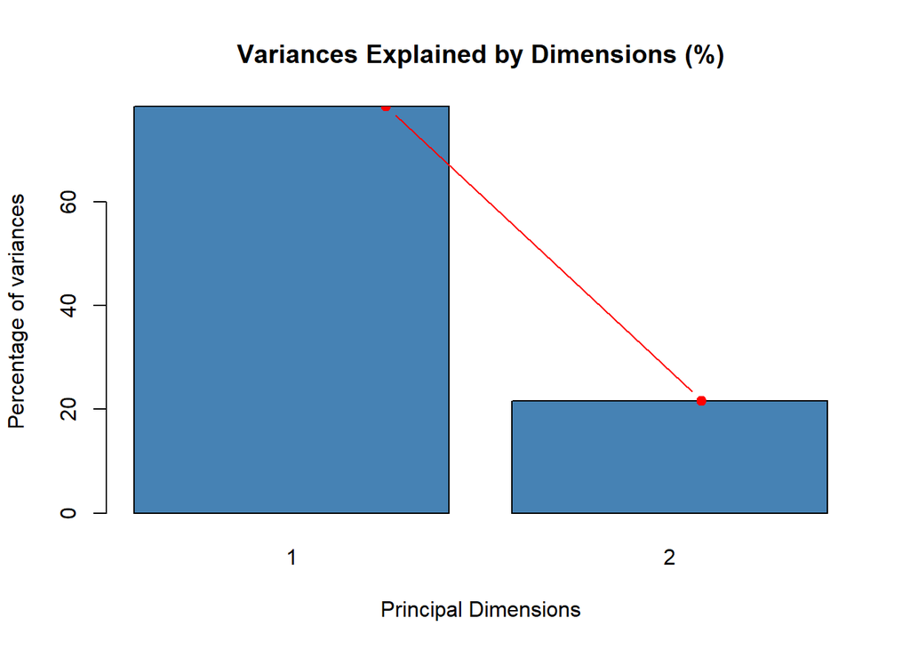

```r
barplot(eig.val[, 2],
        names.arg = 1:nrow(eig.val),
        main = "Variances Explained by Dimensions (%)",
        xlab = "Principal Dimensions",
        ylab = "Percentage of variances",
        col ="steelblue")
# Add connected line segments to the plot
lines(x = 1:nrow(eig.val), eig.val[, 2],
      type = "b", pch = 19, col = "red")
```

On ne peut retenir que deux axes (axes disponibles = min((3-1),(4-1))=2)).

## 6.Représentation et interprétation de la carte des profils-colonnes :

```r
round(cbind(res.ca$col$coord[,1:2],res.ca$col$contrib[,1:2], res.ca$col$cos2[,1:2]),2)
```

```
##                   Dim 1 Dim 2 Dim 1 Dim 2 Dim 1 Dim 2
## 1-2 hours         -0.01  0.77  0.00 80.85  0.00  1.00
## less than 1 hour   2.30 -0.17 89.65  1.84  0.99  0.01
## more than 2 hours -0.27 -0.18 10.35 17.31  0.68  0.32
```

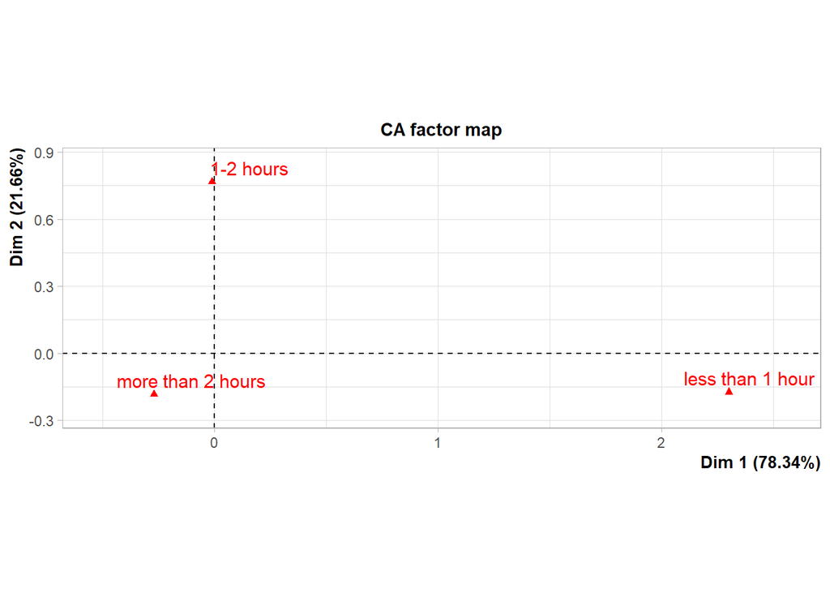

```r
plot(res.ca, invisible="row")
```

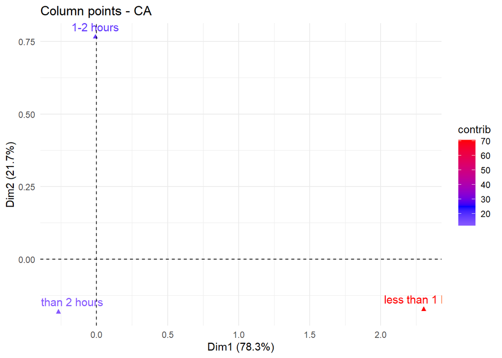

```r
fviz_ca_col(res.ca, col.col = "contrib")+
 scale_color_gradient2(low = "white", mid = "blue",
           high = "red", midpoint = 25) +
 theme_minimal()
```

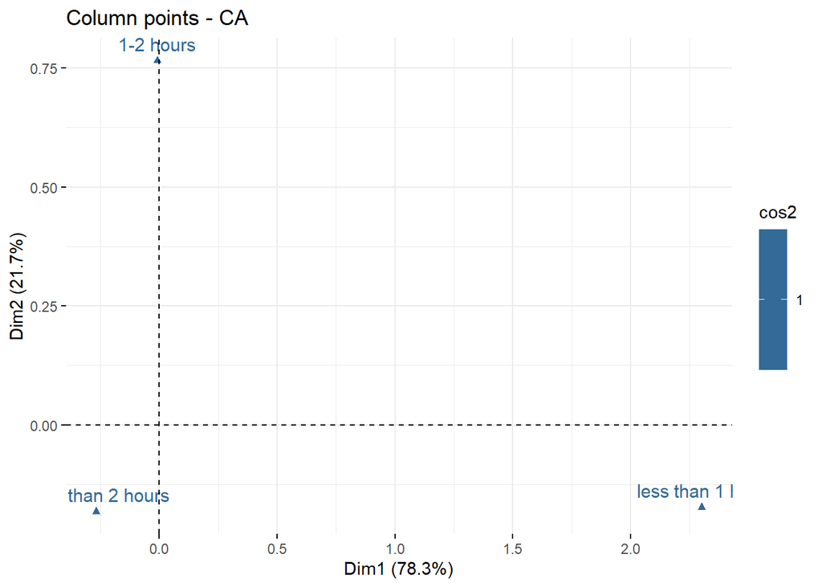

```r
fviz_ca_col(res.ca, col.col="cos2")
```

Le premier axe oppose Less than 1 hour (contrib=89.65%) à more than 2 hours (contrib=10.35%) ce qui signifie que les catégorie socio-professionnelle des personnes qui utilisent les smartphones moins qu’une heure sont différents de ceux qui l’utilisent plus que 2 heures.

## 7.Représentation et interprétation de la carte des profils-lignes :

```r
round(cbind(res.ca$row$coord[,1:2],res.ca$row$contrib[,1:2], res.ca$row$cos2[,1:2]),2)
```

```
##            Dim 1 Dim 2 Dim 1 Dim 2 Dim 1 Dim 2
## employed    0.26  0.79  2.24 75.59  0.10  0.90
## retired     3.25 -0.47 89.11  6.62  0.98  0.02
## Student    -0.22 -0.11  6.84  6.81  0.78  0.22
## unemployed -0.38 -0.49  1.82 10.99  0.37  0.63
```

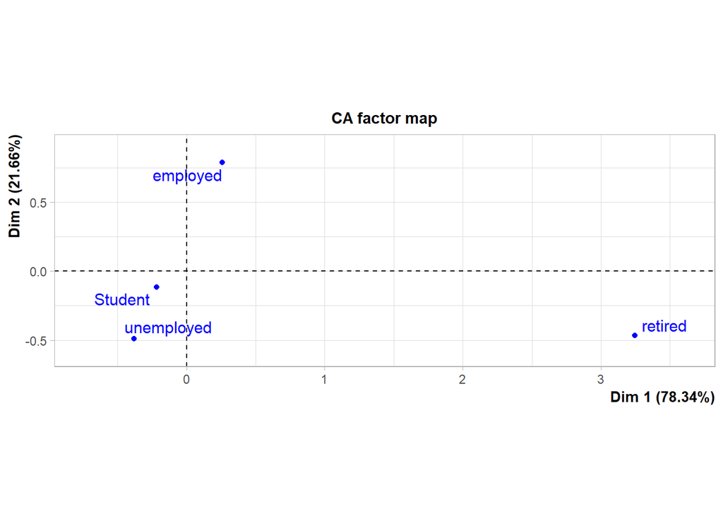

```r
plot(res.ca, invisible="col")
```

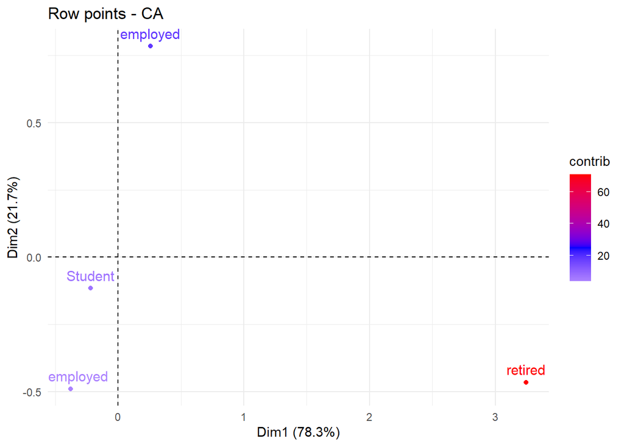

```r
fviz_ca_row(res.ca, col.row = "contrib")+
 scale_color_gradient2(low = "white", mid = "blue",
           high = "red", midpoint = 25) +
 theme_minimal()
```

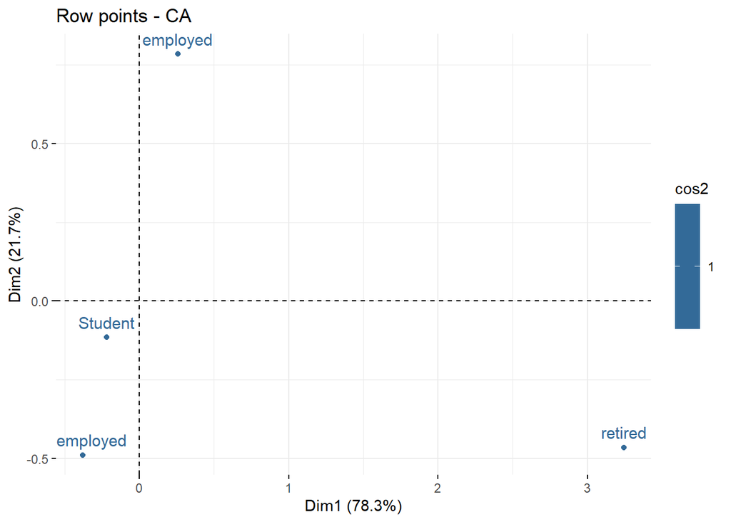

```r
fviz_ca_row(res.ca, col.row = "cos2")
```

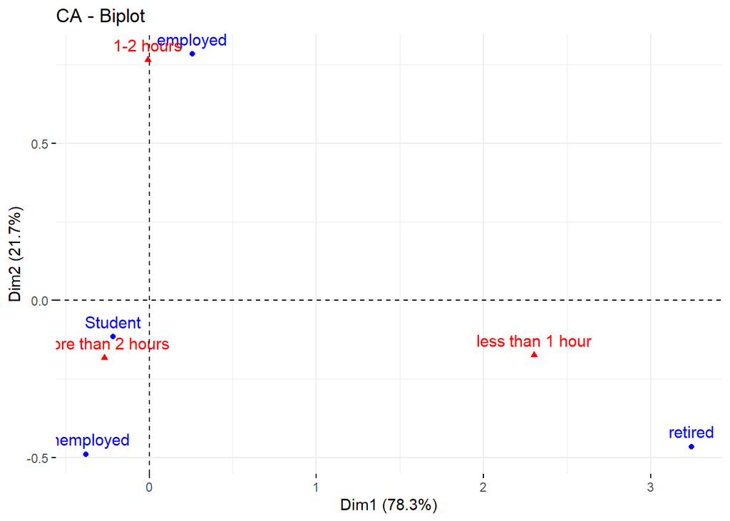

```r
fviz_ca_biplot(res.ca)
```

La carte de représentation simultannée montre une correspondance entre les modalités Student,Unemployed et More than 2hours , Employed et 1-2hours, Retired et Less than 1hour.

Les modalités More than 2 hours a une position centrale dans cette carte. Ceci est dû au fait que les personnes,Student et Unemployed confondus,passent plus que deux heures sur le smartphone.

# IV)ACM:

## 1.Choix de nombre d’axes :

```r
AD[,c(27:35)]
```

```
## # A tibble: 47 x 9
##    Iphone   Samsung   `Huawei]` Iinfinix  Oppo   Lenovo   Honor   OnePlus  IKU
##    <chr>    <chr>     <chr>     <chr>     <chr>  <chr>    <chr>   <chr>    <chr>
##  1 Iphone_y Samsung_y Huawei_n  Infinix_n Oppo_n Lenovo_n Honor_n Oneplus~ Iku_n
##  2 Iphone_y Samsung_y Huawei_n  Infinix_y Oppo_n Lenovo_y Honor_n Oneplus~ Iku_n
##  3 Iphone_y Samsung_y Huawei_n  Infinix_n Oppo_n Lenovo_n Honor_n Oneplus~ Iku_n
##  4 Iphone_n Samsung_n Huawei_y  Infinix_n Oppo_y Lenovo_n Honor_n Oneplus~ Iku_n
##  5 Iphone_n Samsung_n Huawei_y  Infinix_n Oppo_n Lenovo_n Honor_n Oneplus~ Iku_n
##  6 Iphone_n Samsung_y Huawei_n  Infinix_y Oppo_y Lenovo_y Honor_y Oneplus~ Iku_n
##  7 Iphone_y Samsung_y Huawei_n  Infinix_n Oppo_n Lenovo_y Honor_y Oneplus~ Iku_n
##  8 Iphone_y Samsung_y Huawei_n  Infinix_n Oppo_y Lenovo_n Honor_n Oneplus~ Iku_n
##  9 Iphone_y Samsung_y Huawei_n  Infinix_y Oppo_y Lenovo_y Honor_y Oneplus~ Iku_y
## 10 Iphone_y Samsung_y Huawei_n  Infinix_n Oppo_n Lenovo_n Honor_n Oneplus~ Iku_n
## # ... with 37 more rows
```

```r
res.mca <- MCA (AD[,c(27:33)], graph = FALSE)
res.mca$eig
```

```
##       eigenvalue percentage of variance cumulative percentage of variance
## dim 1 0.32654240              32.654240                          32.65424
## dim 2 0.24888826              24.888826                          57.54307
## dim 3 0.12189000              12.189000                          69.73207
## dim 4 0.10261277              10.261277                          79.99334
## dim 5 0.08947236               8.947236                          88.94058
## dim 6 0.06337637               6.337637                          95.27822
## dim 7 0.04721784               4.721784                         100.00000
```

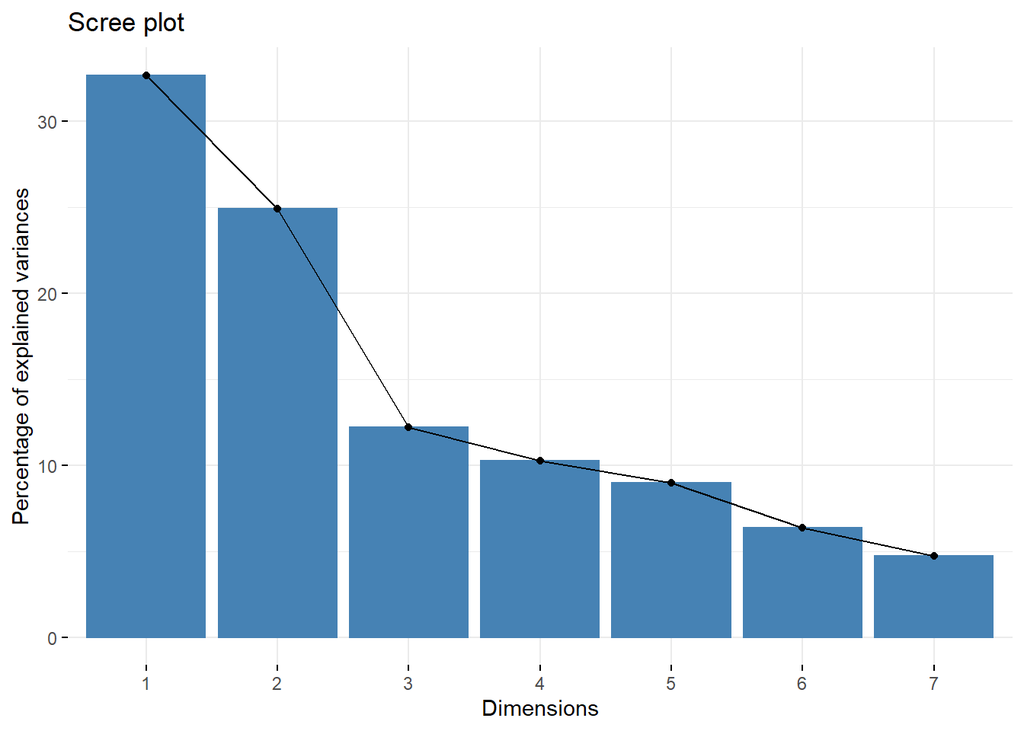

```r
fviz_screeplot(res.mca)
```

Critère 2 : Tracer le graphique des valeurs propres et noter que le coude se trouve au niveau du troisième axe.

Critère 3 : L’inertie cumulée de 2 premies axes est de 57%

Décision : on retient 2 axes.

## 2.Interprétation de la première carte des modalités.

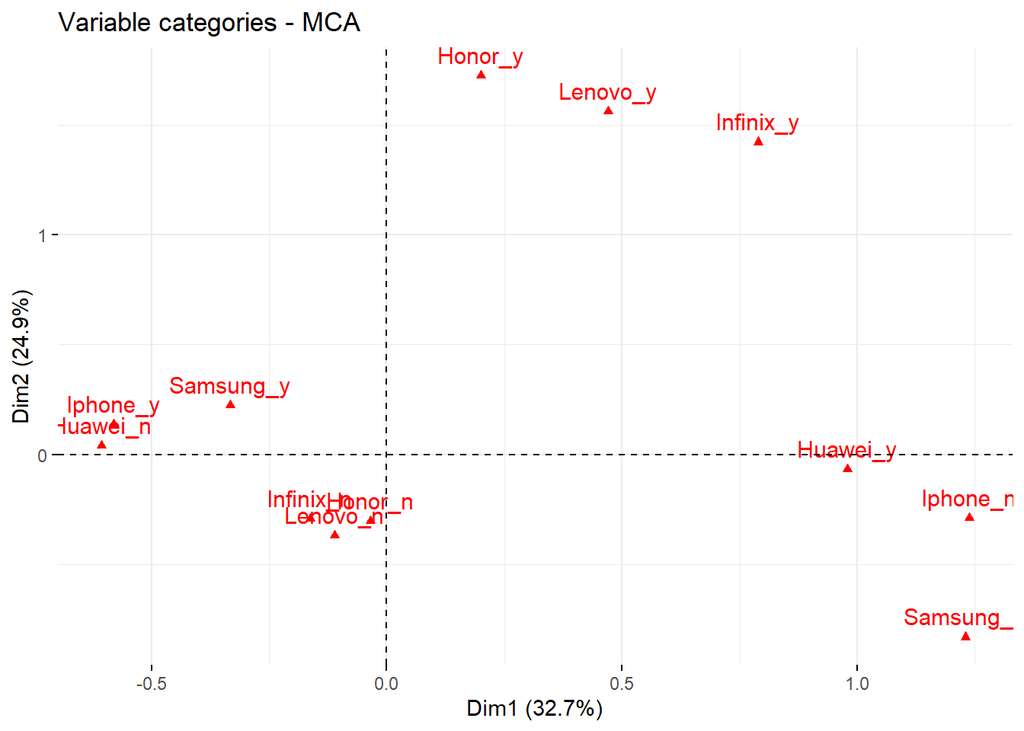

```r
fviz_mca_var(res.mca,select.var = list(cos2 = 0.4))
```

Il suffit d’identifier les groupes de modalités qui sont proches dans la carte. On a un premier groupe de modalités à gauche constitué des modalités Infinix_n, Honor_n, Lenovo_n dont l’interprétation est la suivante : les individus qui qui n’aiment pas une marque non célèbre ont tendance à ne pas se contenter des autres marques dans la même gamme. On a aussi un deuxième groupe a droite constitué de Huawei_y, Iphone_n et Samsung_n dont l’interprtaion est la suivante: les individus qui aiment les smartphones de marque Iphone et Samsung ont tendance à ne pas aimer les Smartphone de marque Huawei ce qui peut être dû à plusieurs facteurs comme la qualité d’image, la performance et réputation dans le marché.

## 3.Interprétation de la première carte des individus.

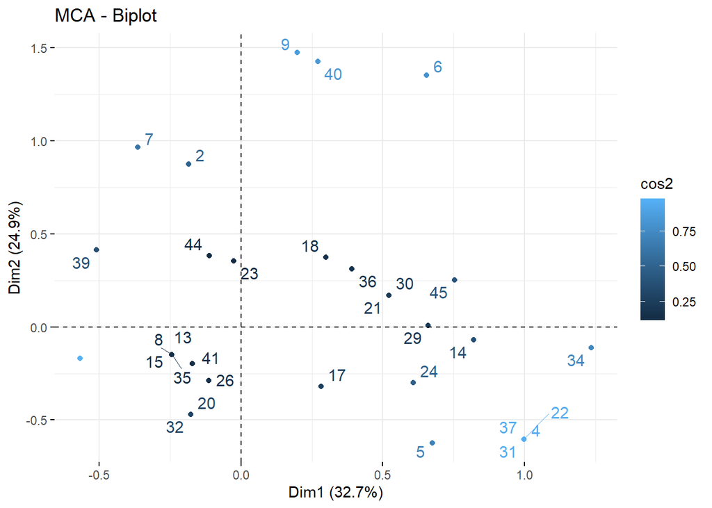

```r
fviz_mca_biplot(res.mca,
               col.ind="cos2",
               invisible ="var",repel = TRUE,
              ggtheme = theme_minimal ())
```

Le premier groupe des indivdus G1=[8,15,13,35,41,26,20,32] est caractérisé par les modalités Infinix_n, Honor_n, Lenovo_n. le deuxième groupe des individus G2=[22,4,37,31] est caractérisé par les modalités Huawei_y, Iphone_n et Samsung_n

# V)Classification:

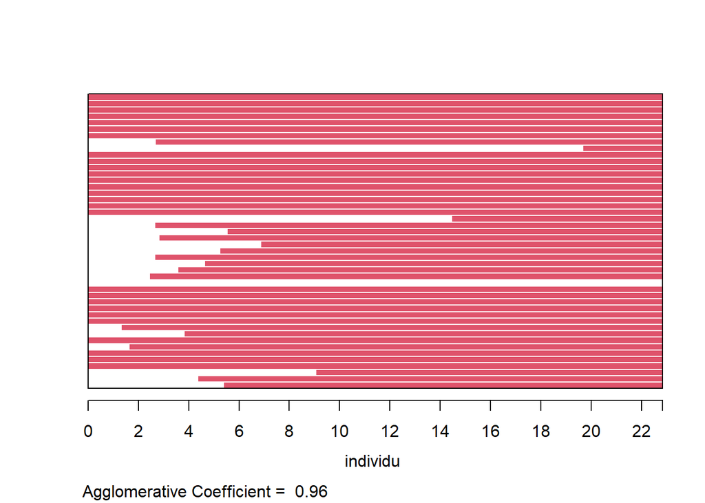

```r
library(cluster)
Utilisation <- AD[,c(7:15)]
classif<-agnes(Utilisation, method="ward")
plot(classif,xlab="individu",main="")
```

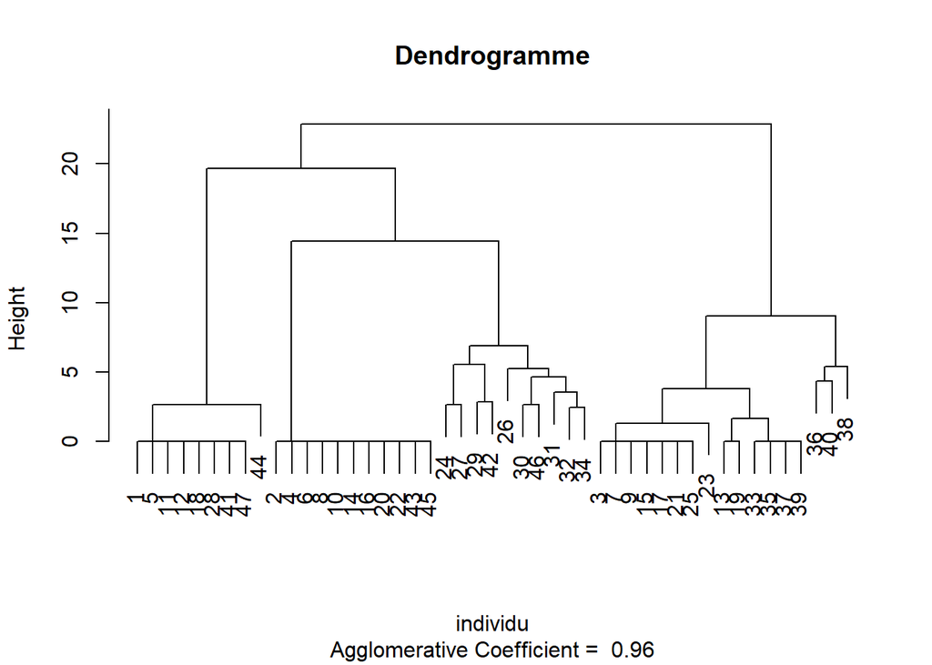

```r
title("Dendrogramme")
```

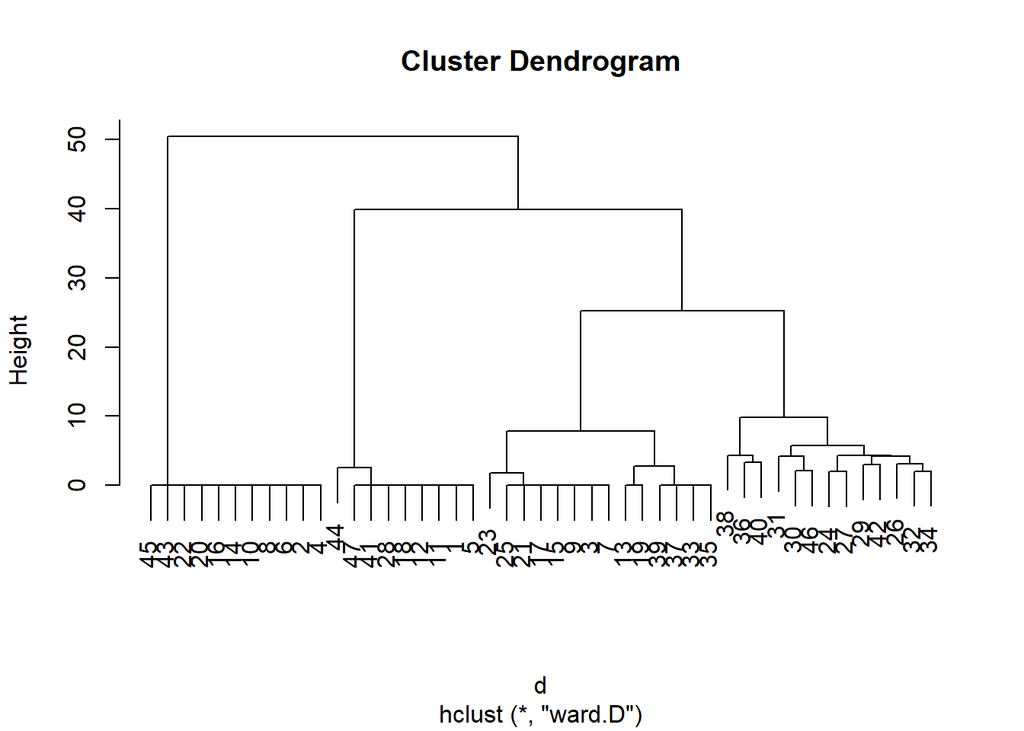

```r
d=dist(scale(Utilisation),method = "euclidian")
hc1=hclust(d,method = "ward.D") # or complete or average
plot(hc1)
```

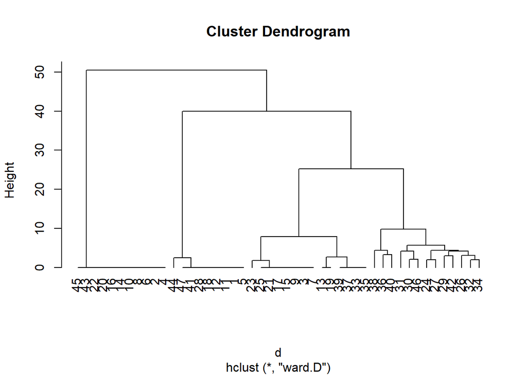

```r
plot(hc1, hang = -1)
```

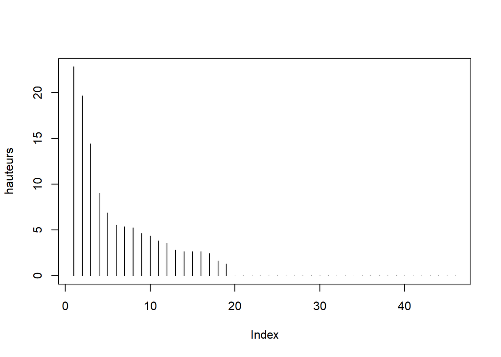

```r
classif2<-as.hclust(classif)
plot(rev(classif2$height), type="h", ylab="hauteurs")
```

De plus le plus haut saut entre deux classes successives entre le 9éme et le 14éme niveau.

```r
#rect.hclust(hc1,k=4)
classes<-cutree(classif2,k=4)
classes
```

```
##  [1] 1 2 3 2 1 2 3 2 3 2 1 1 3 2 3 2 3 1 3 2 3 2 3 4 3 4 4 1 4 4 4 4 3 4 3 3 3 3
## [39] 3 3 1 4 2 1 2 4 1
```

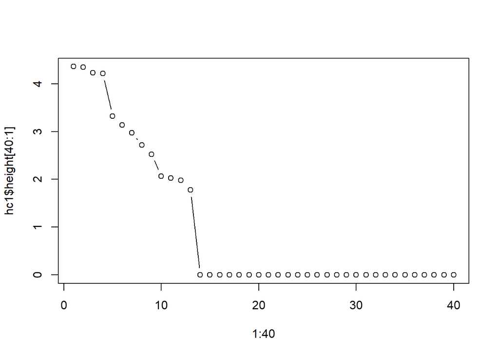

```r
plot(1:40,hc1$height[40:1],type="b")
```

```r
Utilisation.comp<-cbind.data.frame(Utilisation, as.factor(classes))
colnames(Utilisation.comp)[10]<-"Classe"
#head(Utilisation.comp)
```

Un presque effet de coude existe en 4 classes.

```r
res.cat=catdes(Utilisation.comp, num.var=10)
res.cat
```

```
##
## Link between the cluster variable and the quantitative variables
## ================================================================
##               Eta2                              P-value
## E-mails  0.9522772 0.0000000000000000000000000002035168
## News     0.8540785 0.0000000000000000052733546322458284
## Phone_c  0.8471015 0.0000000000000000143384166264665961
## Pictures 0.7955446 0.0000000000000071910827439815557145
## SN       0.7437528 0.0000000000008939364161202849703644
## Music    0.7409131 0.0000000000011309158711133267317429
## Movies   0.6659704 0.0000000002535136683492570674070682
## Study    0.5899284 0.0000000197051323265458083319398574
## Work     0.5844701 0.0000000260720084462943106086950384
##
## Description of each cluster by quantitative variables
## =====================================================
## $`1`
##             v.test Mean in category Overall mean sd in category Overall sd
## News      5.112709         4.888889     2.617021      0.3142697  1.4666968
## Music     2.660022         4.888889     3.489362      0.3142697  1.7366186
## E-mails   2.545565         3.888889     2.829787      0.3142697  1.3732885
## Pictures  2.163679         4.000000     3.127660      0.0000000  1.3307656
## SN        2.139202         4.000000     3.085106      0.0000000  1.4116504
## Movies   -4.160715         1.000000     2.595745      0.0000000  1.2659127
## Study    -4.189586         1.000000     2.234043      0.0000000  0.9722264
## Phone_c  -4.506302         1.111111     2.702128      0.3142697  1.1653671
##                  p.value
## News     0.0000003175721
## Music    0.0078135509460
## E-mails  0.0109100952801
## Pictures 0.0304890029934
## SN       0.0324193071984
## Movies   0.0000317252312
## Study    0.0000279463747
## Phone_c  0.0000065967163
##
## $`2`
##             v.test Mean in category Overall mean sd in category Overall sd
## Phone_c   4.175353                4     2.702128              0   1.165367
## E-mails   3.194678                4     2.829787              0   1.373288
```

[output cut: 26 more lines]

```
## E-mails 0.00000000004579192
##
## $`4`
##            v.test Mean in category Overall mean sd in category Overall sd
## Study    3.865899              3.3     2.234043      0.7810250  0.9722264
## Work     2.897132              3.3     2.659574      1.0049876  0.7794323
## Phone_c  2.716626              3.6     2.702128      0.6633250  1.1653671
## Pictures 2.046375              3.9     3.127660      0.5385165  1.3307656
## E-mails  1.977548              3.6     2.829787      0.4898979  1.3732885
##               p.value
## Study    0.0001106806
## Work     0.0037659120
## Phone_c  0.0065951056
## Pictures 0.0407194739
## E-mails  0.0479797421
```

2- La deuxième classe nous renseigne sur les indvidus qui utilisent le smartphone pour des raisons de communication.

3- La troisième classe nous renseigne sur les indvidus qui utilisent le smartphone pour des raisons de divertissement.

4- La quatrième classe nous renseigne sur les indvidus qui utilisent le smartphone pour tout faire .

Tout cela est expliqué par la valeur de p-value inférieure a 5% et une valeur test superieure a 2 de signes opposés

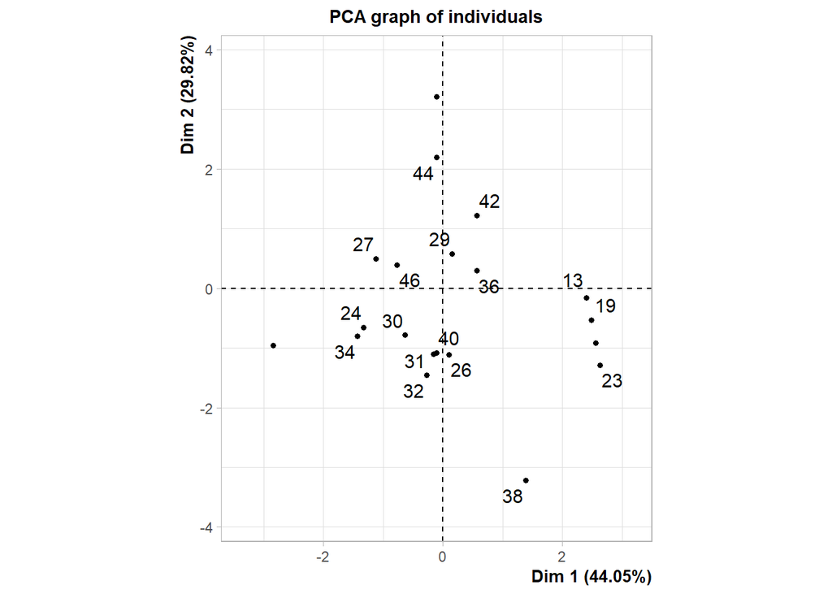

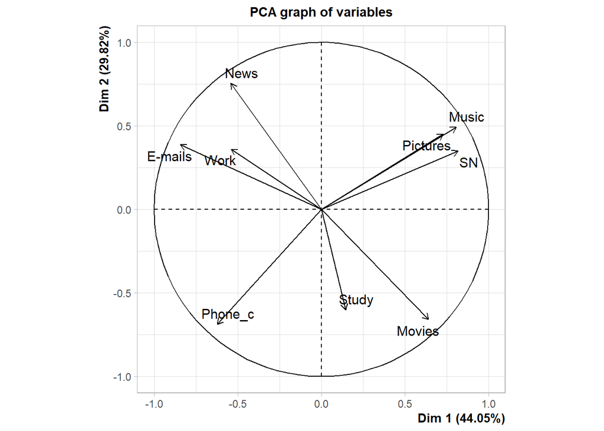

```r
res.pca<-PCA(Utilisation)
```

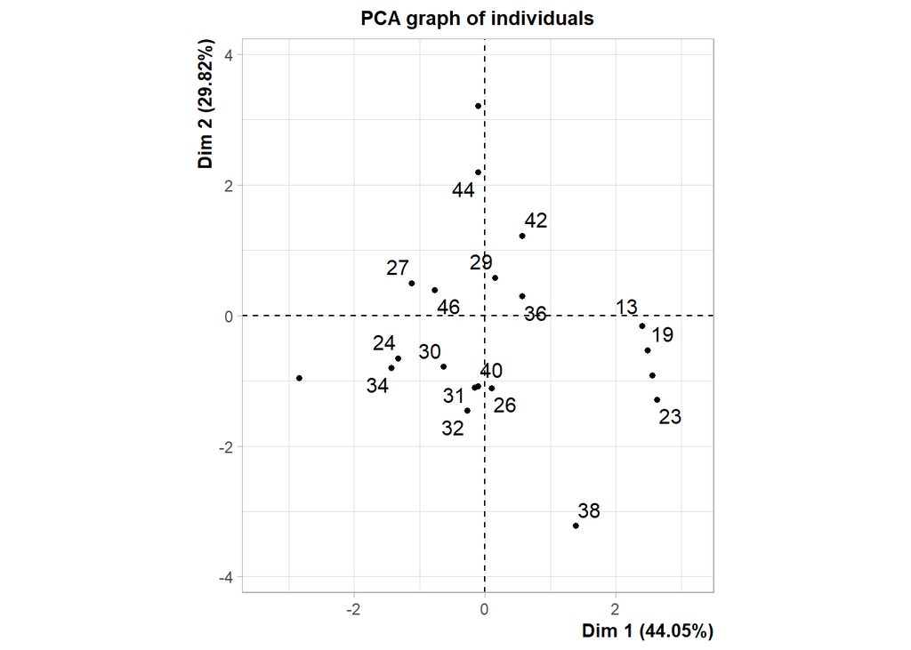

```r
plot(res.pca,choix="ind")
```